# Analisando uma conversa do WhatsApp

Por Henrique Ferreira

## Introdução

Nos últimos anos venho me interessando cada vez mais pela área de Data Science, acompanhando todas as notícias que divulgam essa profissão como "a profissão do futuro". Em Junho de 2019, decidi começar a estudar de maneira autônoma sobre essa carreira, por meio de conteúdos divulgados de maneira gratuita e paga na Internet.

No entanto, senti que somente assistir as vídeo-aulas não era suficiente: eu precisava realmente tentar fazer alguma coisa com os conhecimentos que vinha ganhando. Com isso, busquei pela Internet por bases de dados públicas que podiam ser utilizadas para esse meio.

Foi durante essa busca que surgiu uma ideia: todas as pessoas geram uma quantidade enorme de dados diariamente, logo por quê não analisar dados que foram gerados por mim mesmo?

Portanto, meu primeiro projeto de introdução à Data Science será uma análise das minhas conversas por meio do WhatsApp com minha namorada, visto que acredito descobrir coisas e padrões que nunca teriam passado por nossas cabeças de outra maneira.

## Sobre o Projeto

Durante a execução desse projeto, eu e minha namorada estamos juntos a mais de 2 anos, conversando diariamente sobre assuntos de diversos tipos.

Infelizmente, em Fevereiro, tive a oportunidade de trocar meu celular que me acompanhou por mais de 5 anos, portanto não será possível analisar nossas conversas desde o período em que eramos amigos até o dia de hoje.

Nesse projeto iremos analisar nossa conversa desde o mês de Fevereiro até o mês de Junho.

## Perguntas a Serem Respondidas

- Quem envia mais mensagens?
- Como o dia da semana influencia o número de mensagens enviadas?
- Como a hora do dia influencia o número de mensagens enviadas?
- Quais mensagens são as mais enviadas?

### Importando Bibliotecas que serão utilizadas

```python
import pandas as pd
import matplotlib.pyplot as plt
%matplotlib inline
```

### Importando o dataset e verificando se há valores faltando/em branco

```python
data = pd.read_excel("Chat Data Fixed.xlsx")
df = pd.DataFrame(data)
df.isnull().any()
```

```
DateTime    False
Person      False
Text        False
dtype: bool
```

### A limpeza e estruturação desse Dataset foi realizada diretamente no Excel, portanto podemos partir para a análise dos dados

### Adicionando Novas Colunas

```python
df['Text'] = df.Text.str.lower()
df['TextLen'] = df.Text.str.len()
df['DateTime'] = pd.to_datetime(df.DateTime)
weekdays = ['Monday','Tuesday','Wednesday','Thursday','Friday','Saturday','Sunday']
df['Weekday'] = df['DateTime'].dt.day_name().astype(pd.api.types.CategoricalDtype(categories=weekdays))
df['Hour'] = df.DateTime.dt.hour
df['Date'] = df.DateTime.dt.date
df['Month'] = df.DateTime.dt.month
```

Com as colunas novas adicionadas, podemos analisar de uma maneira mais eficiente nosso dataset. A seguir podemos ver como ficou nosso DataFrame:

```python
df.head()
```

|  | DateTime | Person | Text | TextLen | Weekday | Hour | Date | Month |
| --- | --- | --- | --- | --- | --- | --- | --- | --- |
| 0 | 2019-02-27 22:00:00 | Henrique | que horrivel nao ter as conversas antigas haah... | 50 | Wednesday | 22 | 2019-02-27 | 2 |
| 1 | 2019-02-27 22:00:00 | Victoria | nao fez backup? hahaha | 22 | Wednesday | 22 | 2019-02-27 | 2 |
| 2 | 2019-02-27 22:00:00 | Henrique | de ios pra android nao tem | 26 | Wednesday | 22 | 2019-02-27 | 2 |
| 3 | 2019-02-27 22:00:00 | Victoria | poxa :( | 7 | Wednesday | 22 | 2019-02-27 | 2 |
| 4 | 2019-02-27 22:00:00 | Henrique | credo, bizarro nao ter as conversas antigas ha... | 51 | Wednesday | 22 | 2019-02-27 | 2 |

# Visualizacao dos Dados

## Visão Geral:

### Número total de mensagens enviadas:

```python
print("Numero total de mensagens: ", df.Text.count())
```

```
Numero total de mensagens:  28613
```

### Média por dia:

```python
print("Media diaria de mensagens: ", df.Text.count() / df.Date.nunique())
```

```
Media diaria de mensagens:  283.2970297029703
```

Os dois valores calculados anteriormente servem como um panorama geral antes de adentrarmos em uma analise mais profunda. A partir deles analisaremos como alguns fatores podem afetar o numero de mensagens enviadas e tambem conseguiremos ver algumas curiosidades ao decorrer desse projeto.

## Quem envia mais mensagens?

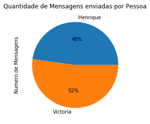

```python
df.groupby("Person").Text.count().plot(kind="pie",autopct='%1.0f%%')
plt.xticks(rotation=0)
plt.ylabel('Numero de Mensagens')
plt.title('Quantidade de Mensagens enviadas por Pessoa')
plt.show()
```

Como podemos ver no gráfico acima, o numero de textos enviados por pessoa esta quase igual. Minha namorada envia poucas mensagens a mais que eu

## Como o mês afeta o numero de mensagens enviadas?

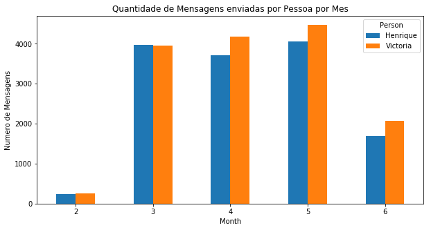

```python
df.groupby(['Month','Person']).Text.count().unstack('Person').sort_values(by="Month").plot(kind="bar", figsize=(10,5))
plt.xticks(rotation=0)
plt.ylabel('Numero de Mensagens')
plt.title('Quantidade de Mensagens enviadas por Pessoa por Mes')
plt.show()
```

Com isso podemos observar que nos meses de Março(3), Abril(4) e Maio(5) o numero de mensagens enviadas nao possui uma grande variancia

No entanto, por que Fevereiro(2) e Junho(6) possuem um numero tao baixo de mensagens enviadas?

```python
print(df.Date.min())
```

```
2019-02-27
```

```python
print(df.Date.max())
```

```
2019-06-13
```

Tendo em vista que dia 13 de Junho é a última data disponível em nosso Dataset (dia em que foi extraida a conversa), esse mês possui 13 dias no total, o que também justifica um número de mensagens enviadas abaixo da média.

## Como o dia da semana afeta o número de mensagens enviadas?

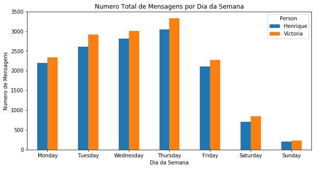

```python
df.groupby(["Weekday","Person"]).Text.count().unstack('Person').sort_values(by="Weekday").plot(kind="bar" ,figsize=(10,5))
plt.xticks(rotation=0)
plt.xlabel('Dia da Semana')
plt.ylabel('Numero de Mensagens')
plt.title('Numero Total de Mensagens por Dia da Semana')
plt.show()
```

A maioria dos Finais de Semana nos passamos juntos, entao esse baixo numero de mensagens enviadas faz sentido. Quinta-feira é o dia em que mandamos mais mensagens, provavelmente por estar marcando os planos para Sábado e Domingo.

No entanto o grafico acima mostra o valor total das mensagens, sera que a media enviada por dia tambem se mantera assim?

Para avaliar isso, irei criar outro DataFrame da seguinte maneira:

```python
df2 = pd.DataFrame(df['Date'].value_counts()).reset_index()
df2.columns = ['Date',"TextN"]
df2['Date'] = pd.to_datetime(df2.Date)
df2['Weekday'] = df2.Date.dt.day_name()
df2.head()
```

|  | Date | TextN | Weekday |
| --- | --- | --- | --- |
| 0 | 2019-03-28 | 641 | Thursday |
| 1 | 2019-05-31 | 608 | Friday |
| 2 | 2019-03-27 | 606 | Wednesday |
| 3 | 2019-06-05 | 562 | Wednesday |
| 4 | 2019-03-13 | 559 | Wednesday |

Com isso, conseguimos avaliar a media de mensagens enviadas por dia da semana:

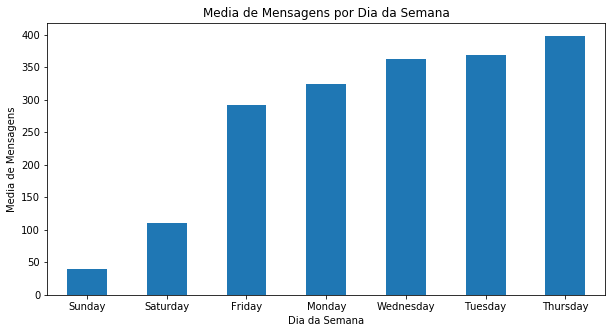

```python
df2.groupby("Weekday").TextN.mean().sort_values(ascending=True).plot(kind='bar',figsize=(10,5))
plt.xticks(rotation=0)
plt.xlabel('Dia da Semana')
plt.ylabel('Media de Mensagens')
plt.title('Media de Mensagens por Dia da Semana')
plt.show()
```

Na grande maioria dos dias a tendencia se mantem igual ao grafico anterior, no entanto Terca-Feira e Quarta-Feira trocaram de posicao, por que?

```python
df2.groupby('Weekday').TextN.count()
```

```
Weekday
Friday       15
Monday       14
Saturday     14
Sunday       11
Thursday     16
Tuesday      15
Wednesday    16
Name: TextN, dtype: int64
```

Domingo e o dia que temos menos registros, devido ao fato de que tendemos a passar os finais de semana juntos.

Sabado ainda contem valores mais relevantes pois geralmente estamos combinando como sera nosso dia.

## Como a hora do dia afeta o numero de mensagens enviadas?

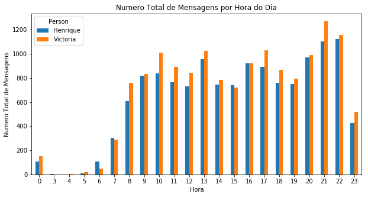

```python
df.groupby(['Hour','Person']).Text.count().unstack('Person').plot(kind="bar",figsize=(10,5))
plt.xticks(rotation=0)
plt.xlabel('Hora')
plt.ylabel('Numero Total de Mensagens')
plt.title('Numero Total de Mensagens por Hora do Dia')
plt.show()
```

Meu dia comeca as 6h da manha e acaba as 23h, visto que estudo no periodo matutino.

Minha namorada estuda a noite, comecando seu dia as 8h e indo dormir por volta de meia-noite.

Portanto, geralmente comecamos a conversar as 8h e paramos as 22h, o que explica os dois picos nesses periodos e a ausencia de mensagens durante 1h e 2h da manha.

Podemos ainda ter uma ideia do horario em que vamos dormir da seguinte maneira:

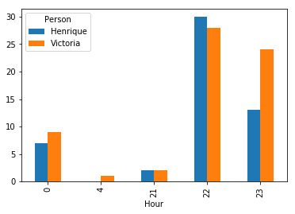

```python
df[df['Text'].str.contains('boa noite|buenas noches')].groupby('Person').Hour.value_counts().unstack('Person').plot(kind="bar")
```

No grafico podemos observar que ha um pico de mensagens de boa noite enviados por mim as 22h. Quando comparamos isso com o grafico das 23h, e possivel notar que o grafico se inverte, o que demonstra que provavelmente eu ja estarei dormindo e minha namorada esta a caminho da cama.

Tambem podemos plotar um grafico para analisar o horario em que acordamos:

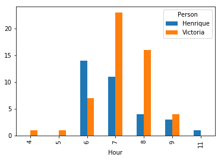

```python
df[df['Text'].str.contains('bom dia|buenos dias')].groupby('Person').Hour.value_counts().unstack('Person').plot(kind="bar")
```

Eu geralmente envio mensagens de bom dia quando estou saindo de casa ou quando chego na faculdade, o que explica essa pequena variancia entre o numero de mensagens entre 6h e 7h; minha namorada tende a acordar por volta das 7h, o que explica o grande pico de mensagens nesse horario.

A seguir vamos analisar a media de mensagens enviadas por hora do dia.

Para isso, precisamos criar novamente um novo dataframe da seguinte maneira:

```python
df3 = df.groupby(['Weekday','Hour']).Text.count()
print(df3.head())
```

```
Weekday  Hour
Monday   0        64
         3         5
         6        22
         7       119
         8       174
Name: Text, dtype: int64
```

Com isso, conseguimos avaliar a media de mensagens enviadas por hora do dia:

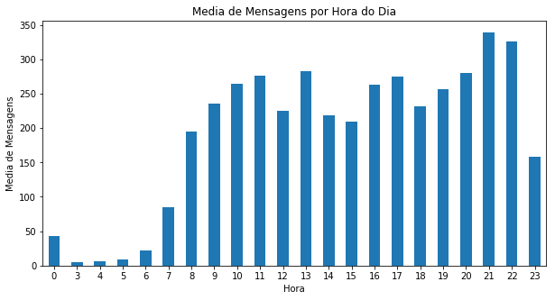

```python
df3.groupby("Hour").mean().plot(kind="bar",figsize=(10,5))
plt.xticks(rotation=0)
plt.xlabel('Hora')
plt.ylabel('Media de Mensagens')
plt.title('Media de Mensagens por Hora do Dia')
plt.show()
```

Por ultimo, vamos analisar como o dia da semana em conjunto com o horario influencia o envio de mensagens:

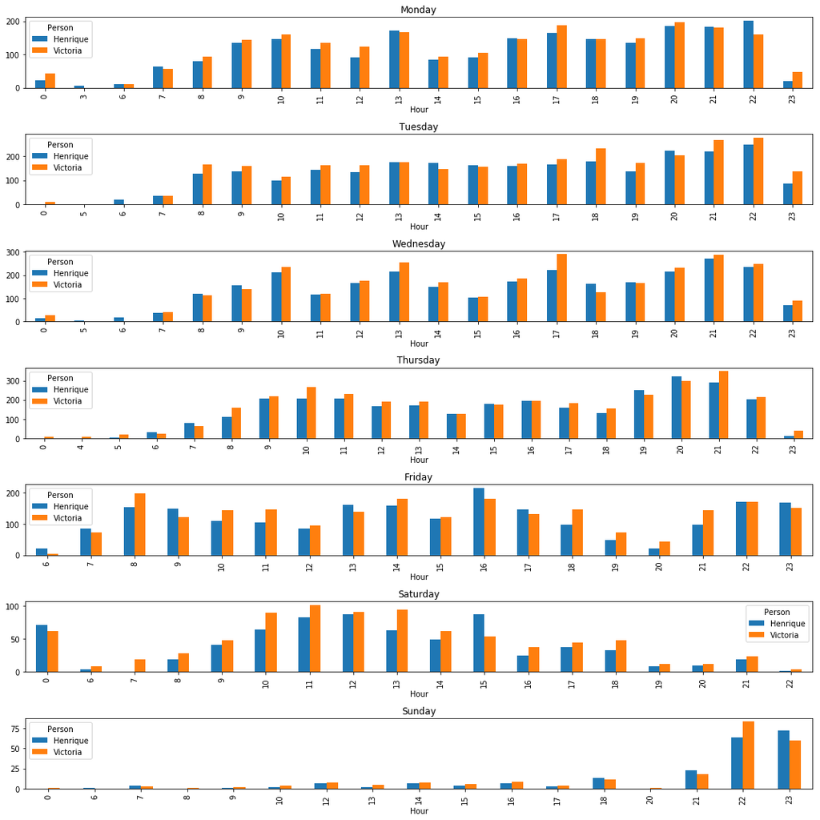

```python
Weekdays = df['Weekday'].sort_values().unique()
fig, axes = plt.subplots(len(Weekdays), 1)

for Weekdays, ax in zip(Weekdays, axes):
    df[df['Weekday'] == Weekdays].groupby(['Person','Hour']).Text.count().unstack('Person').plot(ax=ax,kind="bar",figsize=(15,15))
    ax.set_title(Weekdays)

plt.tight_layout()
```

Dos gráficos plotados anteriormente, um deles se destaca em relação aos demais: durante os domingos, o número de mensagens enviados ao longo do dia é extremamente baixo, sendo que o maior pico de mensagens se da entre 22h e 23h.

Como explicado anteriormente, isso se dá pelo fato de que geralmente passamos grande parte de nossos domingos juntos, sendo que geralmente cada um vai para a sua respectiva casa mais para o fim da noite, onde ocorrem os picos de mensagens.

## Algumas curiosidades:

### Quais são as mensagens enviadas mais frequentemente por pessoa?

#### Henrique:

```python
df[df['Person']=='Henrique'].Text.value_counts().nlargest(5)
```

```
hahaha             676
<media omitted>    429
hahahaha           274
hahahah            198
ah                 141
Name: Text, dtype: int64
```

#### Victoria:

```python
df[df['Person']=='Victoria'].Text.value_counts().nlargest(5)
```

```
<media omitted>    443
hahaha             329
hahahah            327
hahah              179
aham               167
Name: Text, dtype: int64
```

#### Ambos:

```python
df.Text.value_counts().nlargest(5)
```

```
hahaha             1005
<media omitted>     872
hahahah             525
hahahaha            375
okay                232
Name: Text, dtype: int64
```

### Qual o tamanho médio e máximo (em caracteres, contando espaços) das mensagens enviadas por pessoa?

#### Henrique:

```python
print('Tamanho Médio: ', df[df['Person'] == 'Henrique'].TextLen.mean(), "caracteres")
print('Tamanho Máximo: ', df[df['Person'] == 'Henrique'].TextLen.max(), "caracteres")
```

```
Tamanho Médio:  17.891633175009133 caracteres
Tamanho Máximo:  263 caracteres
```

#### Victoria:

```python
print('Tamanho Médio: ', df[df['Person'] == 'Victoria'].TextLen.mean(), "caracteres")
print('Tamanho Máximo: ', df[df['Person'] == 'Victoria'].TextLen.max(), "caracteres")
```

```
Tamanho Médio:  19.573084137191856 caracteres
Tamanho Máximo:  470 caracteres
```

### Qual apelido mais usamos?

Para avaliar isso, listamos abaixo alguns dos apelidos que acreditamos que sao os mais utilizados no dia a dia:

```python
apelidos = ['amor','mozao','mozinho','mozão']
```

Contando todas as ocorrencias dos apelidos descritos anteriormente:

```python
print("Total de ocorrencias por pessoa: ")
print(df[df['Text'].str.contains('|'.join(apelidos))].Person.value_counts())
```

```
Total de ocorrencias por pessoa:
Henrique    167
Victoria     83
Name: Person, dtype: int64
```

Contando o numero de ocorrencias por apelido e por pessoa:

```python
for name in apelidos:
    print("Apelido: ", name.upper())
    print(df[df['Text'].str.contains(name)].Person.value_counts())
    print("")
```

```
Apelido:  AMOR
Victoria    50
Henrique    37
Name: Person, dtype: int64

Apelido:  MOZAO
Henrique    119
Victoria     23
Name: Person, dtype: int64

Apelido:  MOZINHO
Victoria    10
Henrique     6
Name: Person, dtype: int64

Apelido:  MOZÃO
Henrique    5
Name: Person, dtype: int64
```

Portanto, o apelido que mais usamos é "Mozao", que começou a ser usado como uma piadinha por causa da música do Lucas Lucco.